# Airbnb Project

Teresa Graffi

2023-05-27

[figure not shown]

# Big Data Processing with R

# Project on Airbnb data about Paris

The project aims at analyzing Airbnb data regarding the city of Paris, the data was provided into two separate dataframes “L” and “R”. The dataframes have been saved as two separate csv files as “AirbnbL” and “AirbnbR” and reloaded from the file with read.csv(). AirbnbL dataset has 95 variables and 52725 observations, while AirbnbR dataset has 2 variables and 663599 observations.

```
## [1] 52725    95
```

```
## [1] 663599      2
```

We can also inspect the presence of missing values in the two dataframes using the is.na() function. From the output, it is possible to see that AirbnbL has many missing values (279634), while AirbnbR doesn’t present missingness. To better understand the data provided the two datasets will be analysed separately.

```
## Total number of missing values in AirbnbL: 279634
```

```
## Total number of missing values in AirbnbR: 0
```

### Analyzing AirbnbL

The preliminary analysis starts with the printing of the first line of the data to understand how data look like, and an inspection on the datatypes of the variables. Since there are 95 variables in order to have a clear view of the datatypes instead of using str() we can use lapply() with the function class(), and we can group the variables according to their datatype.

```
##        id                          listing_url   scrape_id last_scraped
## 1 4867396 https://www.airbnb.com/rooms/4867396 2.01607e+13   2016-07-03
##                                  name
## 1 Appartement 60m2 Rue Legendre 75017
##                                                                                                                                                                                                                                             summary
## 1 Au 2ème étage d'un bel immeuble joli 2 pièces meublé comprenant: une grande pièce à vivre lumineuse, une chambre, une cuisine, salle de douche et WC séparé. Appartement très calme et lumineux. A proximité de nombreux commerces et transports.
##   space
## 1
##                                                                                                                                                                                                                                         description
## 1 Au 2ème étage d'un bel immeuble joli 2 pièces meublé comprenant: une grande pièce à vivre lumineuse, une chambre, une cuisine, salle de douche et WC séparé. Appartement très calme et lumineux. A proximité de nombreux commerces et transports.
##   experiences_offered neighborhood_overview notes transit access interaction
## 1                none
##   house_rules thumbnail_url medium_url
## 1
##                                                                           picture_url
## 1 https://a1.muscache.com/im/pictures/61090424/02c8a8bb_original.jpg?aki_policy=large
##   xl_picture_url host_id                                  host_url host_name
## 1                9703910 https://www.airbnb.com/users/show/9703910  Matthieu
##   host_since                    host_location host_about host_response_time
## 1 2013-10-29 Nantes, Pays de la Loire, France                           N/A
##   host_response_rate host_acceptance_rate host_is_superhost
## 1                N/A                  N/A                 f
##                                                                                      host_thumbnail_url
## 1 https://a0.muscache.com/im/users/9703910/profile_pic/1383073563/original.jpg?aki_policy=profile_small
##                                                                                           host_picture_url
## 1 https://a0.muscache.com/im/users/9703910/profile_pic/1383073563/original.jpg?aki_policy=profile_x_medium
##   host_neighbourhood host_listings_count host_total_listings_count
## 1        Batignolles                   1                         1
##              host_verifications host_has_profile_pic host_identity_verified
## 1 ['email', 'phone', 'reviews']                    t                      f
##                                             street neighbourhood
## 1 Rue Legendre, Paris, Île-de-France 75017, France   Batignolles
##   neighbourhood_cleansed neighbourhood_group_cleansed  city         state
## 1    Batignolles-Monceau                           NA Paris Île-de-France
##   zipcode market smart_location country_code country latitude longitude
## 1   75017  Paris  Paris, France           FR  France  48.8888  2.320466
##   is_location_exact property_type       room_type accommodates bathrooms
## 1                 t     Apartment Entire home/apt            2         1
##   bedrooms beds bed_type
## 1        1    1 Real Bed
##                                                                              amenities
## 1 {TV,"Cable TV",Internet,"Wireless Internet",Kitchen,Heating,Washer,Dryer,Essentials}
##   square_feet  price weekly_price monthly_price security_deposit cleaning_fee
## 1          NA $60.00      $388.00                        $200.00       $20.00
##   guests_included extra_people minimum_nights maximum_nights calendar_updated
## 1               1        $0.00              1           1125     5 months ago
##   has_availability availability_30 availability_60 availability_90
## 1               NA               0               0               0
##   availability_365 calendar_last_scraped number_of_reviews first_review
## 1                0            2016-07-03                 1   2015-05-19
##   last_review review_scores_rating review_scores_accuracy
## 1  2015-05-19                  100                     10
##   review_scores_cleanliness review_scores_checkin review_scores_communication
## 1                        10                    10                          10
##   review_scores_location review_scores_value requires_license license
## 1                     10                  10                f
##   jurisdiction_names instant_bookable cancellation_policy
## 1              Paris                f            flexible
##   require_guest_profile_picture require_guest_phone_verification
## 1                             f                                f
##   calculated_host_listings_count reviews_per_month
## 1                              1              0.07
```

From the name of the columns and from the data of the two first rows we can understand what each column describe. The variables can be divided into 9 macro categories as follows:

– Identification related columns:

- id: Unique identifier for each Airbnb listing / accommodation.
- listing_url: URL link to the listing on the Airbnb website.
- scrape_id: Unique identifier for the scraping process.
- last_scraped: Date when the listing was last scraped.

– Description related columns:

- name: Name/title of the listing.
- summary: Brief summary description of the accommodation.
- space: Description of the space within the listing.
- description: Detailed description of the accommodation.
- experiences_offered: Information about the experiences offered by the host.
- neighborhood_overview: Overview of the neighborhood where the accommodation is located.
- notes: Additional notes provided by the host.
- transit: Information about transportation options.
- access: Information about how to access the accommodation.
- interaction: Details about the interaction between the host and guests.
- house_rules: Rules set by the host for guests staying.
- thumbnail_url: URL link to a thumbnail image of the listing.
- medium_url: URL link to a medium-sized image of the listing.
- picture_url: URL link to the main picture of the listing.
- xl_picture_url: URL link to an extra-large picture of the listing.

– Host related columns:

- host_id: Unique identifier for the host.
- host_url: URL link to the host’s profile on Airbnb.
- host_name: Name of the host.
- host_since: Date when the host joined Airbnb.
- host_location: Location of the host.
- host_about: Information about the host provided by themselves.
- host_response_time: Time taken by the host to respond to requests.
- host_response_rate: Percentage of requests to which the host has responded.
- host_acceptance_rate: Percentage of booking requests accepted by the host.
- host_is_superhost: Indicator variable (T/F) if the host is a superhost.
- host_thumbnail_url: URL link to the host’s thumbnail profile picture.
- host_picture_url: URL link to the host’s profile picture.
- host_neighbourhood: Neighborhood where the host lives.
- host_listings_count: Total number of accommodations owned by the host.
- host_total_listings_count: Same as host_listings_count.
- host_verifications: Methods used by the host to verify their identity.
- host_has_profile_pic: Indicator variable (T/F) if the host has a profile picture.
- host_identity_verified: Indicator variable (T/F) if the host’s identity is verified.
- calculated_host_listings_count: Number of listings by the host.

– Location related columns:

- street: Address of the accommodation.
- neighbourhood: Neighbourhood name of the accommodation.
- neighbourhood_cleansed: Cleaned column neighbourhood name.
- neighbourhood_group_cleansed: Cleaned column neighbourhood group name.
- city: City of the listing.
- state: State where the listing is located.
- zipcode: Postal code of the listing.
- market: Market where the accommodation is located.
- smart_location: Smart location name.
- country_code: Country code of the accommodation.
- country: Country where the listing is located.
- latitude: Latitude coordinate of the accommodation.
- longitude: Longitude coordinate of the accommodation.
- is_location_exact: Indicator variable (T/F) if the location is exact.

– Accommodation details columns:

- property_type: Type of property (e.g., apartment, house, etc.).
- room_type: Type of room available (e.g., entire home, private room, etc.).
- accommodates: Maximum number of guests the accommodation can accommodate.
- bathrooms: Number of bathrooms.
- bedrooms: Number of bedrooms.
- beds: Number of beds.
- bed_type: Type of bed (e.g., real bed, sofa bed, etc.).
- amenities: List of amenities provided in the listing.
- square_feet: Area of the listing in square feet.

– Price related columns:

- price: Price per night for the accommodation.
- weekly_price: Weekly price for the accommodation.
- monthly_price: Monthly price for the accommodation.
- security_deposit: Amount of security deposit required.
- cleaning_fee: Fee charged for cleaning the accommodation.
- guests_included: Number of guests included in the base price.
- extra_people: Fee charged for additional guests.

– Calendar and Time related columns:

- minimum_nights: Minimum number of nights required for booking.
- maximum_nights: Maximum number of nights allowed for booking.
- calendar_updated: Information about when the calendar was last updated.
- has_availability: Indicator variable (T/F) if the listing has availability.
- availability_30: Number of available days within the next 30 days.
- availability_60: Number of available days within the next 60 days.
- availability_90: Number of available days within the next 90 days.
- availability_365: Number of available days within the next 365 days.
- calendar_last_scraped: Date when the calendar was last scraped.

– Reviews related columns:

- number_of_reviews: Total number of reviews for the accommodation.
- first_review: Date of the first review (less recent).
- last_review: Date of the most recent review.
- review_scores_rating: Rating score based on guest reviews.
- review_scores_accuracy: Rating score for accuracy based on guest reviews.
- review_scores_cleanliness: Rating score for cleanliness based on guest reviews.
- review_scores_checkin: Rating score for check-in process based on guest reviews.
- review_scores_communication: Rating score for communication based on guest reviews.
- review_scores_location: Rating score for location based on guest reviews.
- review_scores_value: Rating score for value based on guest reviews.
- reviews_per_month: Average number of reviews received per month.

– Policies related columns:

- requires_license: Indicator variable (T/F) if a license is required.
- license: License information.
- jurisdiction_names: Names of jurisdictions.
- instant_bookable: Indicator variable (T/F) if instant booking is available.
- cancellation_policy: Policy for canceling bookings.
- require_guest_profile_picture: Indicator variable (T/F) if guest profile picture is required.
- require_guest_phone_verification: Indicator variable (T/F) if guest phone verification is required.

For what concerns datatypes, most of the variables are of type character, some of type integer, and just a few of type numeric. It seems that not all the columns already have the right datatype, for example, price related variables are considered as character while they should be numerical. Moreover there are no variables in date format while there should be, for example, “last_scraped”, and “calendar_last_scraped”.. The first miss classification could be due to the presence of symbols in the price, for example $/£/€. Whereas for the dates probably the format couldn’t be identified and it should be assigned manually.

```
## $character
##  [1] "listing_url"                      "last_scraped"
##  [3] "name"                             "summary"
##  [5] "space"                            "description"
##  [7] "experiences_offered"              "neighborhood_overview"
##  [9] "notes"                            "transit"
## [11] "access"                           "interaction"
## [13] "house_rules"                      "thumbnail_url"
## [15] "medium_url"                       "picture_url"
## [17] "xl_picture_url"                   "host_url"
## [19] "host_name"                        "host_since"
## [21] "host_location"                    "host_about"
## [23] "host_response_time"               "host_response_rate"
## [25] "host_acceptance_rate"             "host_is_superhost"
## [27] "host_thumbnail_url"               "host_picture_url"
```

[output cut: 39 more lines]

#### Assigning the right datatypes

Character variables that should be of type date: last_scraped, host_since, calendar_last_scraped, first_review, last_review. Character variables that should be of type numerical (assigned to character because of the % symbol): host_response_rate, host_acceptance_rate. Character variables that should be of type numerical (assigned to character because of the $ symbol): price, weekly_price, monthly_price, security_deposit, cleaning_fee, extra_people.

- Converting dates into date format:

– last_scraped

```
## Initial datatype of last_scraped: character
```

```
## Number of NAs: 0
```

```
## [1] "2016-07-03"
```

```
## Datatype of last_scraped: Date
```

```
## Number of NAs: 0
```

– host_since

```
## Initial datatype of host_since: character
```

```
## Number of NAs: 0
```

```
## [1] "2013-10-29"
```

```
## Datatype of host_since: Date
```

```
## Number of NAs: 46
```

```
## Number of NAs: 0
```

– calendar_last_scraped

```
## Initial datatype of calendar_last_scraped: character
```

```
## Number of NAs: 0
```

```
## [1] "2016-07-03"
```

```
## Datatype of calendar_last_scraped: Date
```

```
## Number of NAs: 0
```

– first_review

```
## Initial datatype of first_review: character
```

```
## Number of NAs: 0
```

```
## [1] "2015-05-19"
```

```
## Datatype of first_review: Date
```

```
## Number of NAs: 14508
```

```
## Number of NAs: 0
```

– last_review

```
## Initial datatype of last_review: character
```

```
## Number of NAs: 0
```

```
## [1] "2015-05-19"
```

```
## Datatype of last_review: Date
```

```
## Number of NAs: 14509
```

```
## Number of NAs: 0
```

- Converting character values into numeric format removing the % symbol:

After converting them we can compute the mean to see what’s the average response rate (>92%) and acceptance rate (>85%).

– host_response_rate

“host_response_rate” has some values that are not numerical, these are represented with N/A, which could mean that there is no information on the real value. We can still transform the column into numerical but keeping also the categorical version. During the numerical transformation some NA will appear because of the N/A but these values will be input with the average of the column.

```
## [1] "N/A"
```

```
## [1] "30%"
```

```
## Initial datatype of host_response_rate: character
```

```
## Number of NAs: 0
```

```
## Datatype of host_response_rate_num: numeric
```

```
## Number of NAs: 12563
```

```
## Average host_response_rate_num: 92.28056
```

```
## Number of NAs: 0
```

– host_acceptance_rate

Like “host_response_rate”, also “host_acceptance_rate” has some values that are not numerical, represented with N/A. We’re going to input the NAs introduced by coercion with the average of the column.

```
## [1] "N/A"
```

```
## [1] "100%"
```

```
## Initial datatype of host_acceptance_rate: character
```

```
## Number of NAs: 0
```

```
## Datatype of host_acceptance_rate_num: numeric
```

```
## Number of NAs: 15637
```

```
## Average host_acceptance_rate_num: 85.61686
```

```
## Number of NAs: 0
```

- Converting character values into numeric format removing the $ symbol:

Character variables that should be of type numerical (assigned to character because of the $ symbol): price, weekly_price, monthly_price, security_deposit, cleaning_fee, extra_people. To transform them into integer format, the “$” symbol and “,” (used to represent thousands) were removed using the gsub() function with regular expression, and converted into numeric.

– Price column

```
## [1] "$60.00"
```

```
## Initial datatype: character
```

```
## Number of NAs: 0
```

```
## Datatype: numeric
```

```
## Number of NAs: 0
```

– Weekly_price column

From the print of the first 5 values of the column it is possible to see that there are many empty values. What we can do to deal with the empty values is to input them with the corresponding price per night multiplied by 7. Indeed, sometimes Airbnb’s hosts offer a discount when the guests book the accommodation for more than 7 nights, i.e., they stay for at least a whole week. It could be that the weekly price was reported just for accommodations who offer a discount, hence we could fill the empty values with the “standard” price.

```
## [1] "$388.00" ""        "$501.00" ""        ""
```

```
## Initial datatype: character
```

```
## Number of NAs: 0
```

```
## Datatype: numeric
```

```
## Number of NAs: 0
```

– Monthly_price column

Similarly to weekly_price, in monthly_price there are many empty values. In this case we will input them with the corresponding price per night multiplied by 30.

```
## [1] ""          ""          "$1,503.00" ""          ""
```

```
## Initial datatype: character
```

```
## Number of NAs: 0
```

```
## Datatype: numeric
```

```
## Number of NAs: 0
```

– Security_deposit column

Also in the security_deposit column there are empty values. Following the same logic of the previous inputed values, we could fill the empty values in security deposit with the corresponding value of price multiplied by 1.5. This is because the security deposit cost should be proportional to the cost of the accommodation and usually a little bit higher than it.

```
## [1] "$200.00" ""        "$501.00" "$250.00" ""
```

```
## Initial datatype: character
```

```
## Number of NAs: 0
```

```
## Datatype: numeric
```

```
## Number of NAs: 0
```

– Cleaning_fee column

There are many empty values in cleaning_fee as well, in this case we could fill them with 1/4 of the price per night.

```
## [1] "$20.00" ""       ""       ""       ""
```

```
## Initial datatype: character
```

```
## Number of NAs: 0
```

```
## Datatype: numeric
```

```
## Number of NAs: 0
```

– Extra_people column

Extra_people column does not present any missing values or empty values, hence the variable will be just transformed into numeric format.

```
## [1] "$0.00" "$0.00" "$0.00" "$0.00" "$0.00"
```

```
## Initial datatype: character
```

```
## Number of NAs: 0
```

```
## Datatype: numeric
```

```
## Number of NAs: 0
```

#### Missingness and duplicates

– Missingness

```
## Total number of missing values in the dataframe: 279634
```

```
## Total number of columns with missing values in the dataframe: 24
```

```
##                        space        neighborhood_overview
##                            1                            1
##                        notes                      transit
##                            3                            1
##                       access                  interaction
##                            1                            1
##                  house_rules                   host_about
##                            1                            5
##          host_listings_count    host_total_listings_count
##                           46                           46
## neighbourhood_group_cleansed                    bathrooms
##                        52725                          243
##                     bedrooms                         beds
##                          193                           80
##                  square_feet             has_availability
##                        50218                        52725
##         review_scores_rating       review_scores_accuracy
##                        15454                        15575
##    review_scores_cleanliness        review_scores_checkin
##                        15566                        15579
##  review_scores_communication       review_scores_location
##                        15543                        15560
##          review_scores_value            reviews_per_month
##                        15559                        14508
```

To have a clearer view of the missing values we can arrange them from the variable with highest number of NAs to the one with lowest number of NAs. It is possible to notice that the columns neighbourhood_group_cleansed and has_availability have 52725 missing values, which means that all the rows are missing for this two columns. Also square_feet column presents more missing rows than non missing rows (50218 vs 2507). In order to have a dataframe as clean as possible the columns with more NAs than non missing values will be dropped (neighbourhood_group_cleansed, has_availability, square_feet).

```
## Number of missing values in the dataframe in decreasing order:
```

```
##                        variable missing_count
## 1  neighbourhood_group_cleansed         52725
## 2              has_availability         52725
## 3                   square_feet         50218
## 4         review_scores_checkin         15579
## 5        review_scores_accuracy         15575
## 6     review_scores_cleanliness         15566
## 7        review_scores_location         15560
## 8           review_scores_value         15559
## 9   review_scores_communication         15543
## 10         review_scores_rating         15454
## 11            reviews_per_month         14508
## 12                    bathrooms           243
## 13                     bedrooms           193
## 14                         beds            80
## 15          host_listings_count            46
## 16    host_total_listings_count            46
## 17                   host_about             5
## 18                        notes             3
## 19                        space             1
## 20        neighborhood_overview             1
## 21                      transit             1
## 22                       access             1
## 23                  interaction             1
## 24                  house_rules             1
```

```
## Updated number of columns in the dataframe: 100
```

The following graph provides an at-a-glance plot of the missingness inside the dataframe, colouring cells, according to missingness, where green indicates a missing cell and violet indicates a present cell. Using the vis_miss() function it is possible to show how the missing values are distributed. In order to have a clear view, we can visualize just variables with at least 1 missing value and order the columns according to the presence of missing value from highest to lowest, showing next to the name of the column the percentage of missing values for that column. From the plot it is noticeable that the missing values seem to be always in the same rows. Which means that we could drop the rows with many missing values without loosing too many observations.

```
## Missingness distribution in columns with at least 1 NA, decreasing order:
```

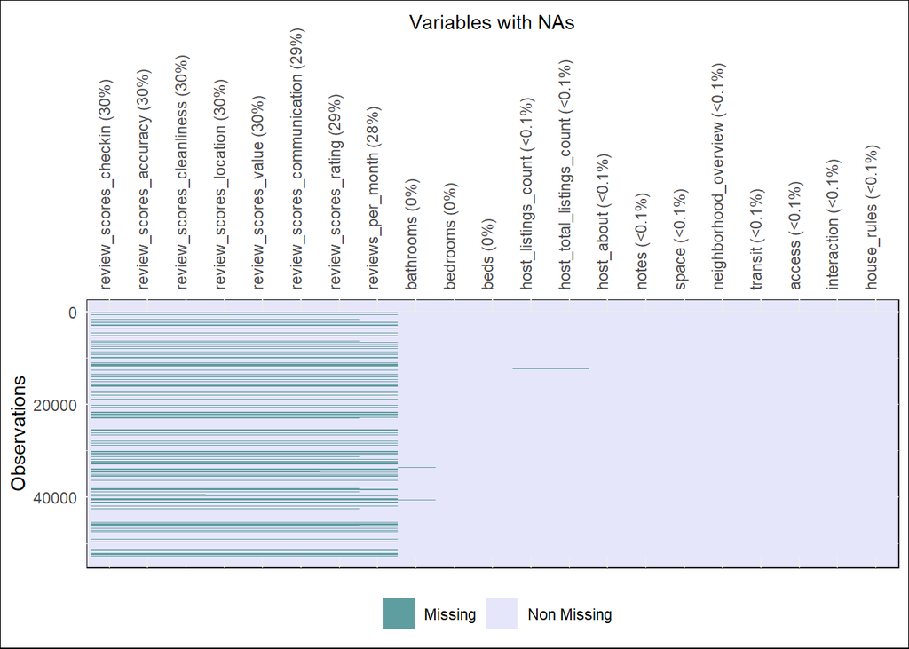

In order to work on a clean dataframe, we can get rid of those rows that present many missing value. This can be done filtering the data frame and keeping only the rows with one or fewer missing values. If we remove rows with more than 1 NA, 15653 rows will be dropped, if we set the condition to more than 2 NAs, 15580 rows will be removed, this means that there are just a few rows with few value missing (73). Similarly, if we set the limit to 3 rows, the number of rows to be removed will be 15541, which is very similar to the number of rows to be removed with the limit set to more than 2 NAs. For this reason, we can set the limit to rows with more than 1 NA and remove them from the dataframe with an anti join. After dropping the rows with more than 1 NA the total number of missing values in the dataframe is 345. We can now see in which columns there are still missing values to understand how we can deal with them.

```
## Starting missingness: 123966
```

```
##                       space       neighborhood_overview
##                           1                           1
##                       notes                     transit
##                           3                           1
##                      access                 interaction
##                           1                           1
##                 house_rules                  host_about
##                           1                           5
##         host_listings_count   host_total_listings_count
##                          46                          46
##                   bathrooms                    bedrooms
##                         243                         193
##                        beds        review_scores_rating
##                          80                       15454
##      review_scores_accuracy   review_scores_cleanliness
##                       15575                       15566
##       review_scores_checkin review_scores_communication
##                       15579                       15543
##      review_scores_location         review_scores_value
##                       15560                       15559
##           reviews_per_month
##                       14508
```

```
## Ending missingness: 345
```

There are 12 columns that still present missing values. Depending on whether the variables are numeric or categorical we decide how to input the missing value. For example, notes and host_about are categorical and require a small text, in order not to provide false information we can input the value “Not specified”. For numeric and integers value we can compute the average value and input that.

```
## Number of columns that present missingness: 12
##  Columns that present missingness: notes host_about bathrooms bedrooms beds review_scores_rating review_scores_accuracy review_scores_cleanliness review_scores_checkin review_scores_communication review_scores_location review_scores_value
```

```
## Number of NAs in notes: 1
```

```
## Number of NAs in host_about: 3
```

```
## Number of NAs in bathrooms: 140
```

```
## Number of NAs in bedrooms: 136
```

```
## Number of NAs in beds: 6
```

```
## Number of NAs in review_scores_rating: 13
```

```
## Number of NAs in review_scores_accuracy: 5
```

```
## Number of NAs in review_scores_cleanliness: 4
```

```
## Number of NAs in review_scores_checkin: 8
```

```
## Number of NAs in review_scores_communication: 8
```

```
## Number of NAs in review_scores_location: 14
```

```
## Number of NAs in review_scores_value: 7
```

```
## The datatype of notes is: character
```

```
## The datatype of host_about is: character
```

```
## The datatype of bathrooms is: numeric
```

```
## The datatype of bedrooms is: integer
```

```
## The datatype of beds is: integer
```

```
## The datatype of review_scores_rating is: integer
```

```
## The datatype of review_scores_accuracy is: integer
```

```
## The datatype of review_scores_cleanliness is: integer
```

```
## The datatype of review_scores_checkin is: integer
```

```
## The datatype of review_scores_communication is: integer
```

```
## The datatype of review_scores_location is: integer
```

```
## The datatype of review_scores_value is: integer
```

```
## Number of NAs in notes: 0
```

```
## Number of NAs in host_about: 0
```

```
## Number of NAs in bathrooms: 0
```

```
## Number of NAs in bedrooms: 0
```

```
## Number of NAs in beds: 0
```

```
## Number of NAs in review_scores_rating: 0
```

```
## Number of NAs in review_scores_accuracy: 0
```

```
## Number of NAs in review_scores_cleanliness: 0
```

```
## Number of NAs in review_scores_checkin: 0
```

```
## Number of NAs in review_scores_communication: 0
```

```
## Number of NAs in review_scores_location: 0
```

```
## Number of NAs in review_scores_value: 0
```

```
## Ending missingness in the whole dataframe: 0
```

– Duplicates

Using the duplicated() function an inspection on duplicates is performed. The dataframe does not seem to present duplicated rows; it is possible to check for duplicates in the “id” column as well to be sure that any accommodation was reported twice with different information for each observation. There are no duplicates in the IDs neither.

```
## Number of duplicates in the dataframe: 0
```

```
## Number of duplicated IDs: 0
```

#### Analysis of data according to datatype

We can describe the numerical columns using the summary() function to see minimum value, 1st quantile, median, mean, 3rd quantile, maximum value, and in case the number of missing values. This analysis won’t be performed on IDs, latitude and longitude since their analysis won’t provide useful information. From this tables, insights on the distribution of the variables can be obtained. For example, in most numeric variables minimum value, 1st quantile, median, and 3rd quantile present similar values while mean and maximum values are higher (in same cases way more higher), this means that the distribution is skewed and that there are few higher values that have a strong influence on the distribution of the variable.

There are many variables where the maximum value is really high with respect to mean and other indicators, this could be due to the presence of outliers or to a very heterogeneous dataset. This is the case for host_listings_count (1024), host_total_listings_count (1024), minimum_nights (1000), number_of_reviews (392), calculated_host_listings_count (155), reviews_per_month (14), price_num (2004), weekly_price_num (14028), monthly_price_num (56220), security_deposit_num (4708), cleaning_fee_num (751), extra_people_num (351). For the number of listings and minimum nights, the maximum value is an outlier, given that it’s highly unlikely that one host has 1024 listings (also because the maximum computed count is 155 which is more likely) or that to book an accommodation guests should stay at least 1000 nights, which is almost 3 years. For the number of reviews, the maximum value can be explained by the fact that there are listings that joined Airbnb many years ago and that could have already welcomed many guests. For reviews per month, it could be that there are some accommodations that prefer short stays (maximum 2 nights). For the variables related to price, it could be that there are some very expensive accommodations, since Paris is a city well-known for luxury, and there could be guests that opt for an airbnb apartment instead that a five-star hotel.

```
##  host_listings_count host_total_listings_count  accommodates      bathrooms
##  Min.   :   0.000    Min.   :   0.000          Min.   : 1.000   Min.   :0.000
##  1st Qu.:   1.000    1st Qu.:   1.000          1st Qu.: 2.000   1st Qu.:1.000
##  Median :   1.000    Median :   1.000          Median : 2.000   Median :1.000
##  Mean   :   4.958    Mean   :   4.958          Mean   : 3.066   Mean   :1.083
##  3rd Qu.:   2.000    3rd Qu.:   2.000          3rd Qu.: 4.000   3rd Qu.:1.000
##  Max.   :1024.000    Max.   :1024.000          Max.   :16.000   Max.   :8.000
##     bedrooms           beds        guests_included  minimum_nights
##  Min.   : 0.000   Min.   : 0.000   Min.   : 0.000   Min.   :   1.000
##  1st Qu.: 1.000   1st Qu.: 1.000   1st Qu.: 1.000   1st Qu.:   1.000
##  Median : 1.000   Median : 1.000   Median : 1.000   Median :   2.000
##  Mean   : 1.047   Mean   : 1.687   Mean   : 1.426   Mean   :   3.032
##  3rd Qu.: 1.000   3rd Qu.: 2.000   3rd Qu.: 2.000   3rd Qu.:   3.000
##  Max.   :10.000   Max.   :16.000   Max.   :16.000   Max.   :1000.000
##  maximum_nights      availability_30 availability_60 availability_90
##  Min.   :1.000e+00   Min.   : 0.00   Min.   : 0.00   Min.   : 0.00
##  1st Qu.:6.000e+01   1st Qu.: 1.00   1st Qu.: 5.00   1st Qu.:11.00
##  Median :1.125e+03   Median : 9.00   Median :27.00   Median :41.00
##  Mean   :1.775e+05   Mean   :11.62   Mean   :27.82   Mean   :42.47
##  3rd Qu.:1.125e+03   3rd Qu.:22.00   3rd Qu.:49.00   3rd Qu.:74.00
##  Max.   :2.147e+09   Max.   :30.00   Max.   :60.00   Max.   :90.00
##  availability_365 number_of_reviews review_scores_rating review_scores_accuracy
##  Min.   :  0.0    Min.   :  1.00    Min.   : 20.00       Min.   : 2.000
##  1st Qu.: 41.0    1st Qu.:  3.00    1st Qu.: 87.00       1st Qu.: 9.000
##  Median :224.0    Median :  7.00    Median : 93.00       Median :10.000
##  Mean   :196.7    Mean   : 17.83    Mean   : 91.04       Mean   : 9.413
##  3rd Qu.:337.0    3rd Qu.: 20.00    3rd Qu.: 97.00       3rd Qu.:10.000
##  Max.   :365.0    Max.   :392.00    Max.   :100.00       Max.   :10.000
##  review_scores_cleanliness review_scores_checkin review_scores_communication
##  Min.   : 2.00             Min.   : 2.000        Min.   : 2.000
##  1st Qu.: 9.00             1st Qu.: 9.000        1st Qu.: 9.000
##  Median : 9.00             Median :10.000        Median :10.000
##  Mean   : 9.11             Mean   : 9.597        Mean   : 9.653
##  3rd Qu.:10.00             3rd Qu.:10.000        3rd Qu.:10.000
##  Max.   :10.00             Max.   :10.000        Max.   :10.000
##  review_scores_location review_scores_value calculated_host_listings_count
##  Min.   : 2.000         Min.   : 2.000      Min.   :  1.000
##  1st Qu.: 9.000         1st Qu.: 9.000      1st Qu.:  1.000
##  Median :10.000         Median : 9.000      Median :  1.000
##  Mean   : 9.443         Mean   : 9.181      Mean   :  3.722
```

[output cut: 8 more lines]

```
##  Max.   :14.290    Max.   :100.00         Max.   :100.00
##    price_num       weekly_price_num  monthly_price_num security_deposit_num
##  Min.   :   0.00   Min.   :    0.0   Min.   :    0     Min.   :  15.0
##  1st Qu.:  55.00   1st Qu.:  351.8   1st Qu.: 1470     1st Qu.: 102.0
##  Median :  75.00   Median :  501.0   Median : 2004     Median : 200.0
##  Mean   :  93.72   Mean   :  630.9   Mean   : 2513     Mean   : 296.1
##  3rd Qu.: 105.00   3rd Qu.:  701.0   3rd Qu.: 2850     3rd Qu.: 401.0
##  Max.   :2004.00   Max.   :14028.0   Max.   :56220     Max.   :4708.0
##  cleaning_fee_num extra_people_num
##  Min.   :  0.00   Min.   :  0.000
##  1st Qu.: 15.00   1st Qu.:  0.000
##  Median : 23.75   Median :  0.000
##  Mean   : 29.89   Mean   :  6.256
##  3rd Qu.: 40.00   3rd Qu.: 10.000
##  Max.   :751.00   Max.   :351.000
```

For categorical variables we can use the str() function to see how many values/levels are there for each factor. For variables with few levels we can use the table() function to see the frequency of each value of the variable.

```
## 'data.frame':    37072 obs. of  59 variables:
##  $ listing_url                     : chr  "https://www.airbnb.com/rooms/4867396" "https://www.airbnb.com/rooms/9337509" "https://www.airbnb.com/rooms/12928158" "https://www.airbnb.com/rooms/2728649" ...
##  $ name                            : chr  "Appartement 60m2 Rue Legendre 75017" "Charming flat near Batignolles" "Spacious bedroom near the centre of Paris" "Heart of Batignolles - 2 bedrooms" ...
##  $ summary                         : chr  "Au 2ème étage d'un bel immeuble joli 2 pièces meublé comprenant: une grande pièce à vivre lumineuse, une chambr"| __truncated__ "Welcome to my apartment ! This a quiet and cosy flat with 2 room (25 sqm2) fully furnished closed to trendy Bat"| __truncated…
##  $ space                           : chr  "" "" "" "" ...
##  $ description                     : chr  "Au 2ème étage d'un bel immeuble joli 2 pièces meublé comprenant: une grande pièce à vivre lumineuse, une chambr"| __truncated__ "Welcome to my apartment ! This a quiet and cosy flat with 2 room (25 sqm2) fully furnished closed to trendy Bat"| __truncated…
##  $ experiences_offered             : chr  "none" "none" "none" "none" ...
##  $ neighborhood_overview           : chr  "" "" "" "" ...
##  $ notes                           : chr  "" "" "" "" ...
##  $ transit                         : chr  "" "" "" "Métro Brochant (at 5 mn by walk)" ...
##  $ access                          : chr  "" "" "" "" ...
##  $ interaction                     : chr  "" "" "" "" ...
##  $ house_rules                     : chr  "" "" "" "No smoking" ...
##  $ thumbnail_url                   : chr  "" "" "https://a2.muscache.com/im/pictures/df47511b-0e86-4dcb-9887-569489b16020.jpg?aki_policy=small" "" ...
##  $ medium_url                      : chr  "" "" "https://a2.muscache.com/im/pictures/df47511b-0e86-4dcb-9887-569489b16020.jpg?aki_policy=medium" "" ...
```

[output cut: 45 more lines]

– host_is_superhost column

The number of superhosts is significantly smaller than the number of “normal” hosts. Probably the super_host feature is not well-known from many hosts or it could be very hard to be classified as super_host.

```
## Frequency table of host_is_superhost:
```

```
##
##     f     t
## 34962  2110
```

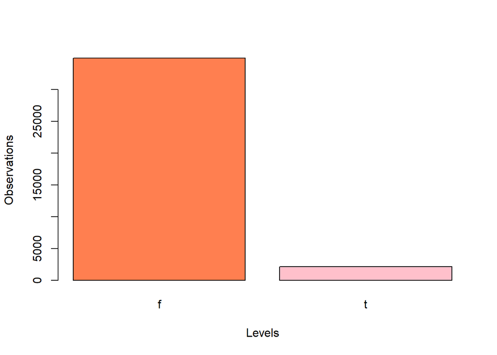

– host_response_time column

From the bar plot it is possible to notice that most of the hosts respond quickly (within an hour or a few). The orange bar shows N/A values which are values that have not been assigned, probably the response time couldn’t be computed or it was a very large value, i.e., not a rapid answer. A quick response from the host is very important, the client must be sure that in case of problems or other necessities, his host will be available and will get in touch rapidly.

```
## Frequency table of host_response_time:
```

```
##
## a few days or more                N/A       within a day within a few hours
##                695               4816               7832              11296
##     within an hour
##              12433
```

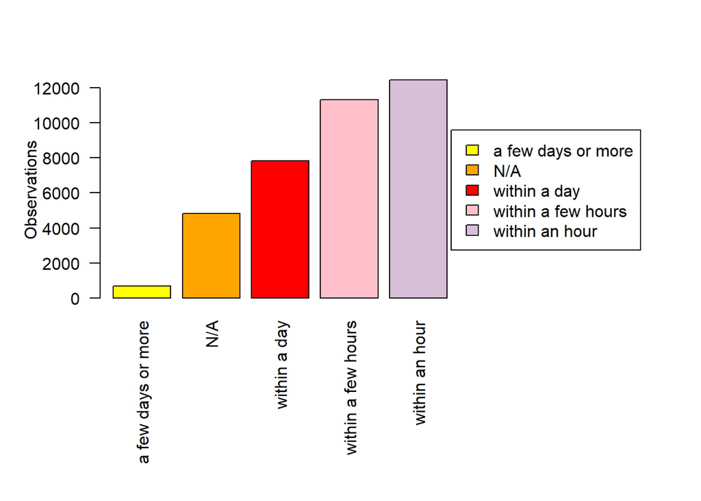

– host_has_profile_pic column

From the frequency table and from the barplot, it can be seen that almost every host has a profile picture, which is good from the point of view of clients, since they can see the people that are offering them a place to sleep. There are just 73 hosts without a profile picture.

```
## Frequency table of host_has_profile_pic:
```

```
##
##     f     t
##    73 36999
```

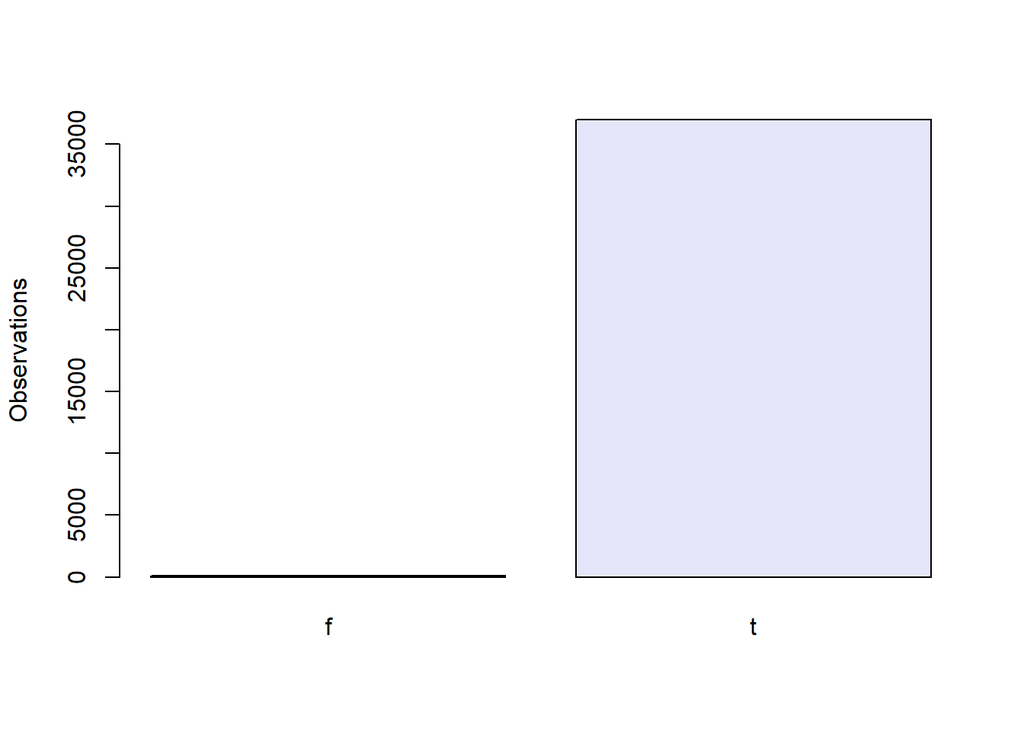

– neighbourhood_cleansed column

There are 20 major neighborhoods, with some exceptions all neighborhoods have similar number of observations. The areas with more observations could be residential areas or areas that are not too pricy. Whereas the neighborhood with less observations could be areas which are very expensive.

```
## Frequency table of neighbourhood_cleansed:
```

```
##
## Batignolles-Monceau              Bourse     Buttes-Chaumont   Buttes-Montmartre
##                2289                1293                1804                4139
##              Élysée            Entrepôt            Gobelins      Hôtel-de-Ville
##                1031                2542                1273                1464
##              Louvre          Luxembourg        Ménilmontant        Observatoire
##                 862                1407                1858                1461
##               Opéra      Palais-Bourbon            Panthéon               Passy
##                1649                1180                1526                1914
##          Popincourt             Reuilly              Temple           Vaugirard
##                3525                1478                1742                2635
```

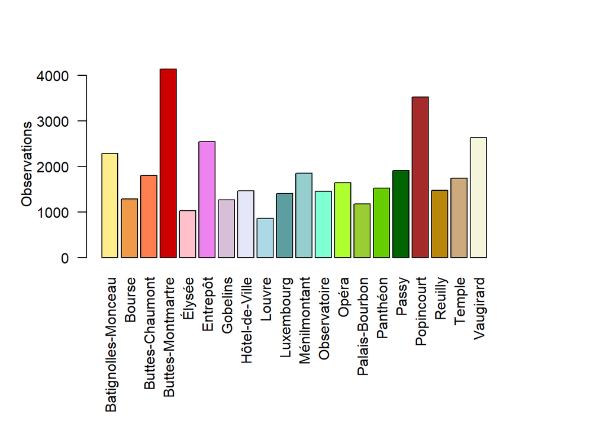

– room_type column

The great majority of room_type are private accommodations, which means that the client will have the whole apartment/house for him. Still, there are some private rooms (4665) where the client stays in a shared apartment but in a private room, and there are also some shared rooms available (382).

```
## Frequency table of room_type:
```

```
##
## Entire home/apt    Private room     Shared room
##           32025            4665             382
```

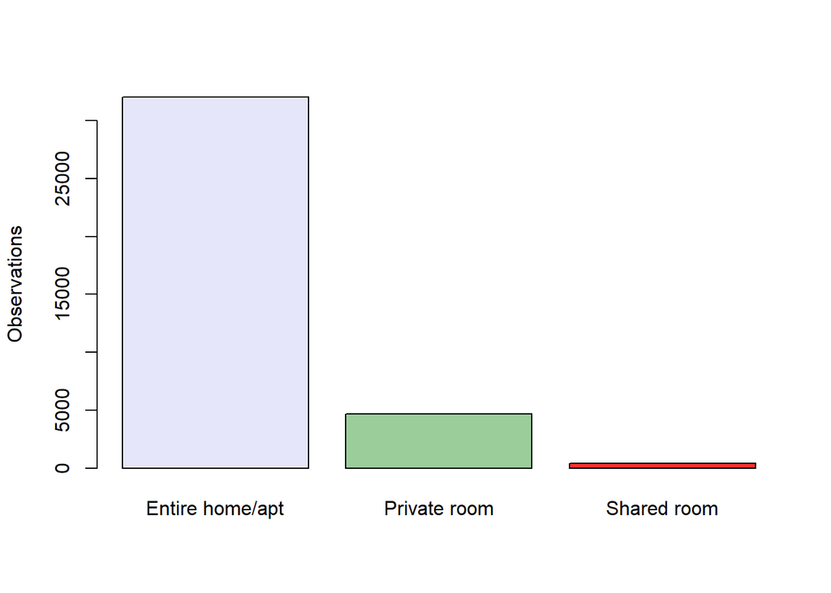

– cancellation_policy column

There are 4 different cancellation policies: flexible, moderate, strict, superstrict 30. The most frequent cancellation policy is the strict one, but there is not a big difference with flexible policy and moderate policy. The observations are almost equally distributed in this 3 policies, whereas there are just 3 accommodations with a superstrict policy.

```
## Frequency table of cancellation_policy:
```

```
##
##        flexible        moderate          strict super_strict_30
##           10454           12034           14581               3
```

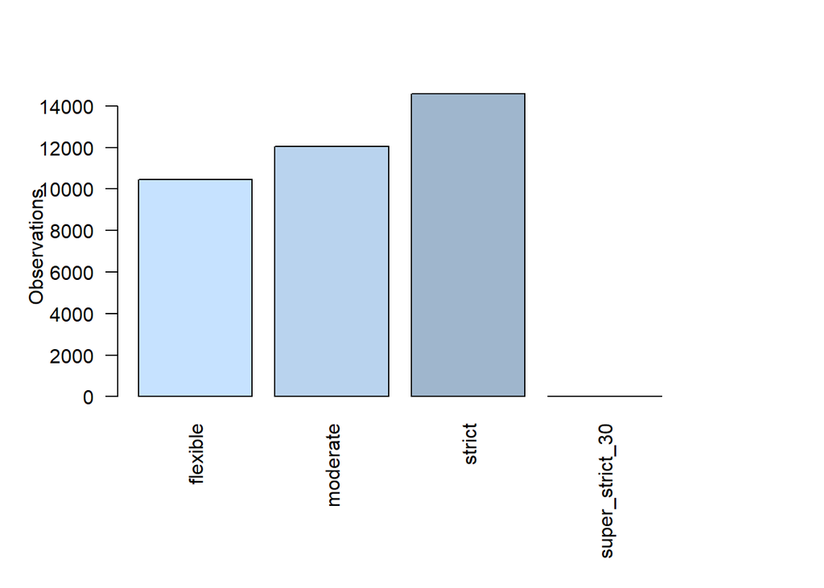

- Price related Data

Price is one of the most important features of the data because it is decisive when dealing with bookings. There are 7 indicators for the price: price, weekly_price, monthly_price, security_deposit, cleaning_fee, guests_included, and extra_people. Initially, in the dataframe the variables related to price were of type character because they presented a dollar sign at the front, it was possible to transform them into numerical in the “Assigning the right datatypes” section.

– Price column

```
## Average price of listings: 93.72491
```

```
## Most frequent price: 60
```

```
## Median: 75
```

From the output we can see that the average price of listing is 93, while mode and median are respectively 60 and 75. Both mode and median are significantly smaller than the mean, which means that the distribution is highly skewed and that most of the observations have a price smaller than 75. At the same time this output highlights that there are few accommodations that are very expensive. This observation can be confirmed plotting the distribution of the price, with an histogram and a boxplot. The same holds for derived column like weekly price and monthly price. Usually to book a whole week of accommodation or a whole month, there are some discounts, but overall the distribution remains unchanged.

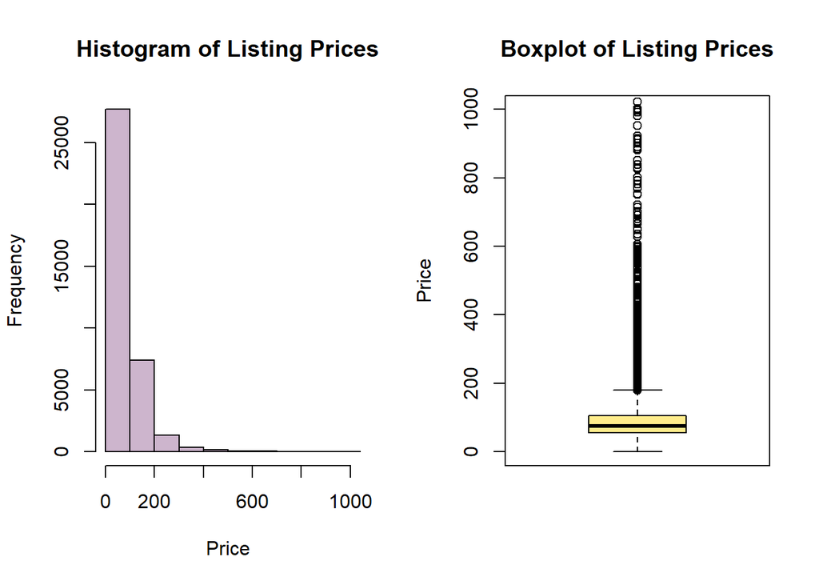

– Weekly_price column

```
## Average weekly_price of listings: 630.8976
```

```
## Median: 501
```

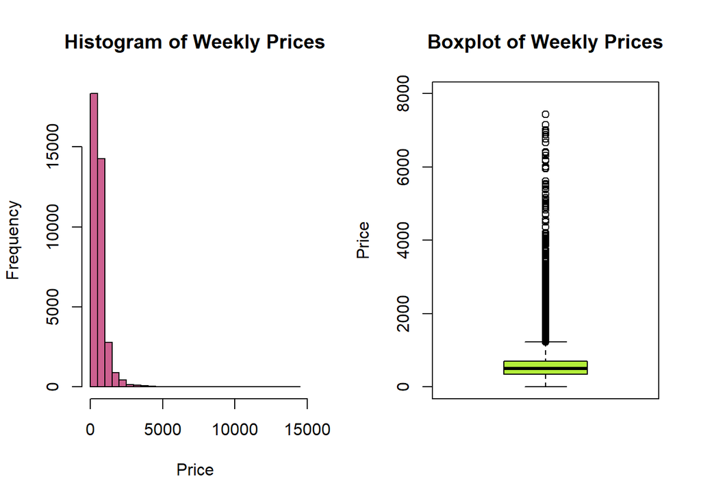

– Monthly_price column

```
## Average monthly_price of listings: 2512.508
```

```
## Median: 2004
```

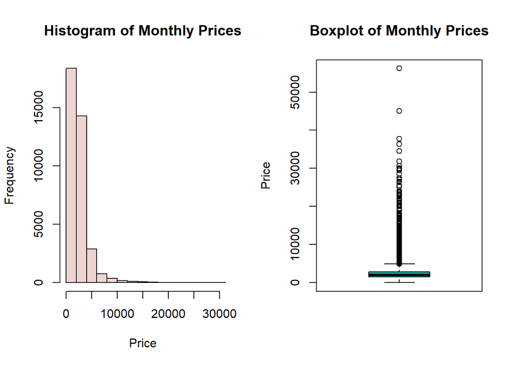

– Security_deposit column

For what concerns the Security Deposit, the distribution happens to be skewed but there are many more high values with respect to the price per night. Indeed, from the boxplot, it is possible to see that the box is higher which means that the observations are slightly more heterogeneous. Moreover there are many outliers with very high values (up to 4700). The values of the security deposit range from 15 to 4708, which are values that differ a lot from each other.

[output not shown]

```
## Median: 200
```

```
## The minimum price for security deposit is   15
##  The maximum price for security deposit is  4708
```

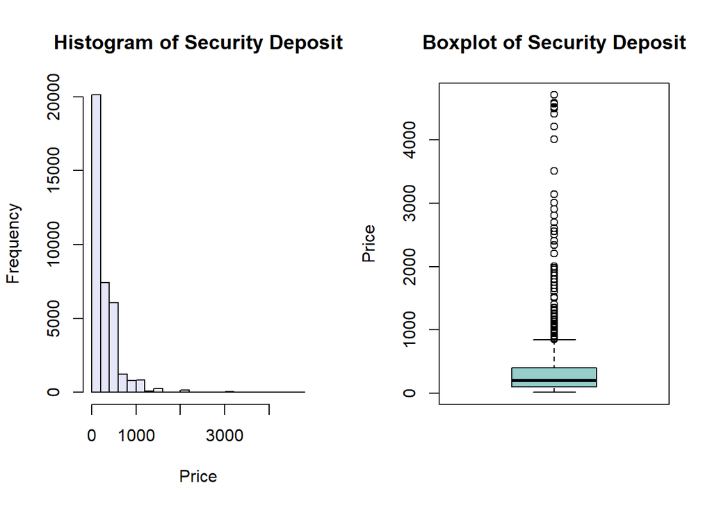

– Cleaning_fee column

The average price for the cleaning fee is 29, the minimum price is 0 and the maximum 751. However most of the observations range between 0 and less than 50.

```
## Average cleaning_fee of listings: 29.88914
```

```
## Median: 23.75
```

```
## The minimum price for cleaning fee is   0
##  The maximum price for cleaning fee is  751
```

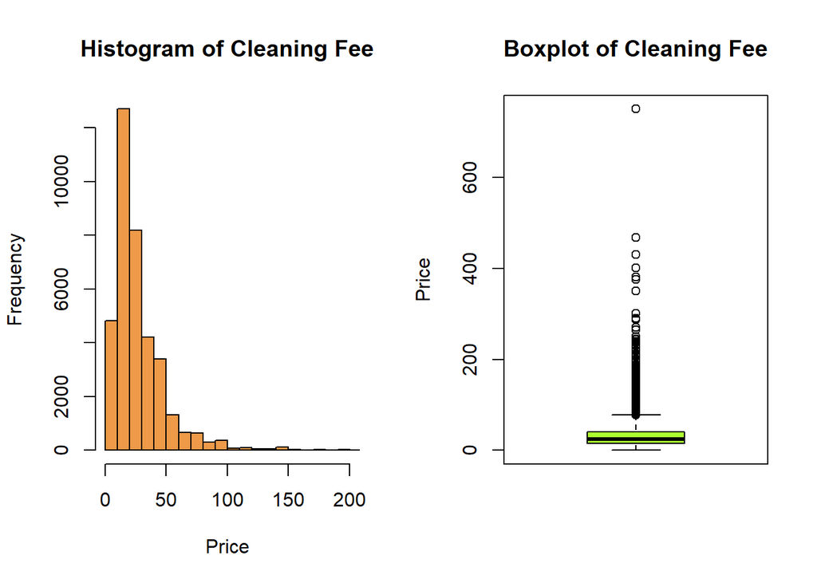

– Extra_people column

Extra_people column contains the price to pay to add other people in the reservation. The average price is 6 but most observations have no additional fees for extra people. Whereas the maximum fee for adding extra people is 351$.

```
## Average cost for extra_people: 6.255773
```

```
## Median: 0
```

```
## The minimum price for extra people is   0
##  The maximum price for extra people is  351
```

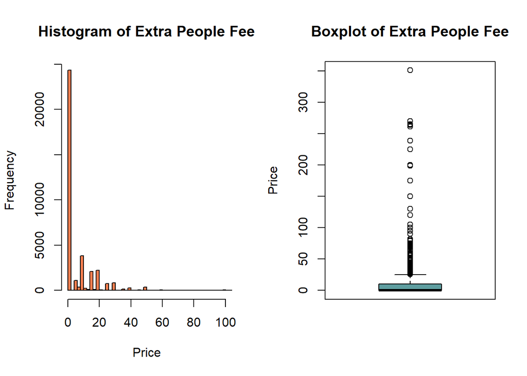

– Guests_included column

The guest_included column is not strictly related to pricing, but it is related to the extra_people variable. Indeed, it represents the number of guests that are included in the accommodation. The minimum value of included guests is 0, while most of the observations have at least 1 guest included. The majority of values ranges between 1 and 3 but there are some exceptions, indeed the maximum value of included guests is 16.

```
## Average number of guests included: 1.425928
```

[output not shown]

```
## The minimum number of guests included  is  0
##  The maximum number of guests included is  16
```

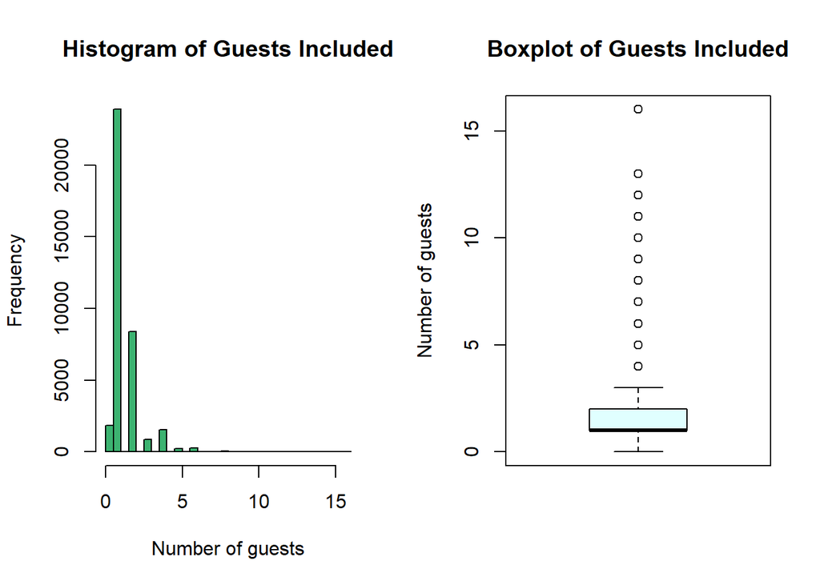

- Location related Data

The variables regarding the location of the accommodations are: neighborhood, neighborhood_overview, street, neighborhood_cleansed, neighborhood_group_cleansed, city, state, zipcode, country, latitude, longitude, is_location_exact, smart_location. The most common way to distinguish neighborhoods in Paris is the number of arrondissement. In order to extract it we can start from the neighborhood columns. Of course it must be cleaned since the division in neighborhoods was made both using arrondissement nomenclature and the name of the area of the accommodation. Due to this inconsistency in the data, it is better to extract the arrondissement from the zipcode (last 2 digits). However not all accommodations are in the city center, some are in the neighborhoods in the nearbies. To deal with these we could extract the first 2 digits instead of the last two in order to identify them, but this is just an approximation. During the creation of arrondissement 255 NAs appeared which will be filled with the arrondissements observed more frequenty (choosing between those from 1 to 20).

```
## Number of listings in each neighborhood:
```

```
##
##                                                                    Alésia
##                                 4605                                 1058
##                           Austerlitz                              Auteuil
##                                   43                                  489
##                             Bastille                          Batignolles
##                                 1262                                 1219
##                                Bercy           Bourse (II Arrondissement)
##                                  246                                   10
##         Buttes-Chaumont - Belleville                   Canal Saint-Martin
##                                 1476                                  425
##                               Cannes                       Champs-Elysées
##                                    1                                  637
##    Châtelet - Les Halles - Beaubourg                   Commerce - Dupleix
##                                 1103                                  671
## Enclos-St-Laurent (X Arrondissement)                         Gare de Lyon
##                                    5                                  245
##         Gare du Nord - Gare de I'Est   Hotel-de-Ville (IV Arrondissement)
##                                  994                                    5
##                     I Arrondissement                    II Arrondissement
##                                    1                                  584
##                   III Arrondissement          Invalides - Ecole Militaire
##                                  561                                  321
##                    IV Arrondissement                    IX Arrondissement
##                                  148                                    4
##                          La Chapelle                          La Villette
##                                  933                                  596
##                            Le Marais                   Louvre - Tuileries
##                                 1335                                  155
##                  Madeleine - Vendôme                              Monceau
##                                  181                                  230
##                           Montmartre                         Montparnasse
##                                 2088                                  434
##                               Nation          Notre Dame - Ile de La Cité
##                                  728                                  102
##            Opéra - Grands Boulevards                         Palais Royal
##                                  442                                  335
##                             Panthéon                                Passy
##                                  735                                  821
##         Père Lachaise - Ménilmontant              Pigalle - Saint-Georges
```

[output cut: 10 more lines]

```
##                                  432                                  334
##          Temple (III Arrondissement)                               Ternes
##                                    4                                  513
##          Tour Eiffel - Champ de Mars         Tour Eiffel - Champs de Mars
##                                  861                                   22
##                            Vaugirard                    VI Arrondissement
##                                  522                                    2
##                     X Arrondissement                    XI Arrondissement
##                                  181                                 1174
##                  XIII Arrondissement                   XIV Arrondissement
##                                    5                                    1
##                    XV Arrondissement                   XVI Arrondissement
##                                    5                                   13
##                  XVII Arrondissement
##                                    1
```

```
## Number of missing values created:  255
```

```
## Number of listings in each neighborhood:
```

```
##
##    1    2    3    4    5    6    7    8    9   10   11   12   13   14   15   16
##  856 1273 1610 1465 1533 1401 1116  985 1641 2586 3523 1405 1239 1436 2609 1821
##   17   18   19   20   22   70   78   79   92   93   94   95
## 2240 4130 1762 1878    1    2    1    1  166   46   87    4
```

```
## Number of missing values left:  0
```

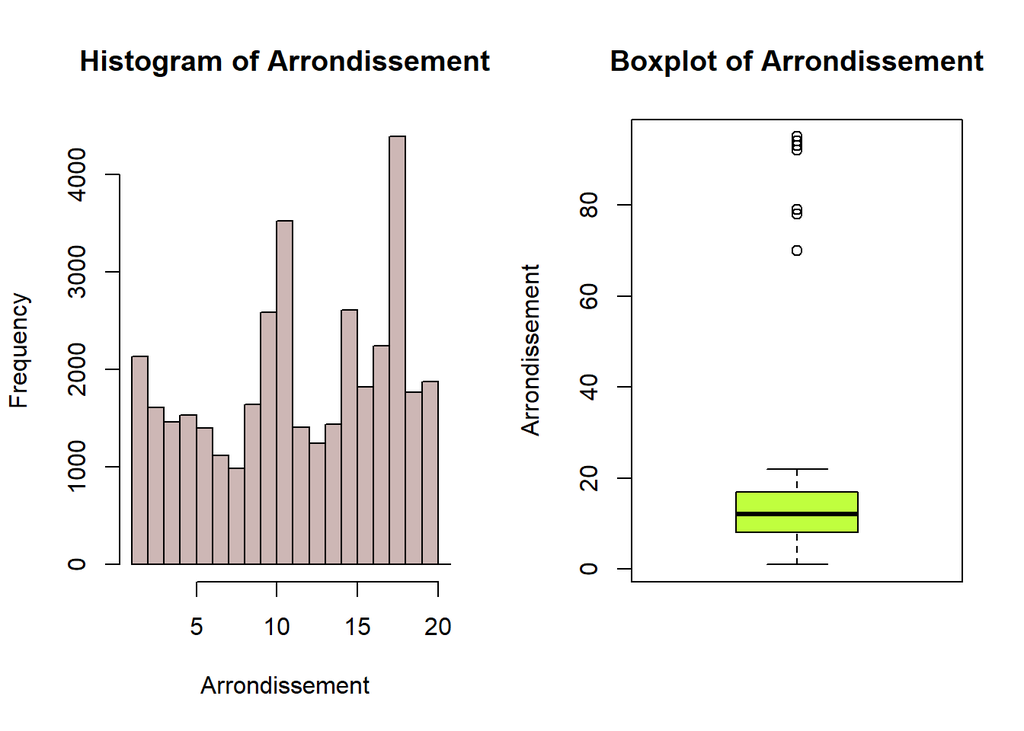

With the Arrondissement variable we can also compute the average price per Arrondissement and plot it.

```
## Average price per arrondissement:
```

```
##    arrondissement price_num
## 1               1 136.81542
## 2               2 112.20189
## 3               3 114.46957
## 4               4 131.32560
## 5               5 113.75016
## 6               6 138.67095
## 7               7 135.67652
## 8               8 155.91371
## 9               9  95.84644
## 10             10  79.80936
## 11             11  78.67868
## 12             12  76.89039
## 13             13  69.91445
## 14             14  82.26880
## 15             15  87.54810
## 16             16 115.07688
## 17             17  86.27009
## 18             18  74.26819
## 19             19  65.87230
## 20             20  61.88498
## 21             22  89.00000
## 22             70 229.50000
## 23             78  59.00000
## 24             79  40.00000
## 25             92  73.76506
## 26             93  53.06522
## 27             94  69.27586
## 28             95  28.25000
```

The following plot shows just arrondissements from 1st to 20th. The price is on the y axis and the bars are coloured according to increasing price, which means that darker bars are arrondissements where the price is on average higher. It can be clearly seen that arrondissements from 1st to 8th are generally more expensive, whereas from 9th to 20th the average price does not exceed 100 with the exception of the 16th arrondissement.

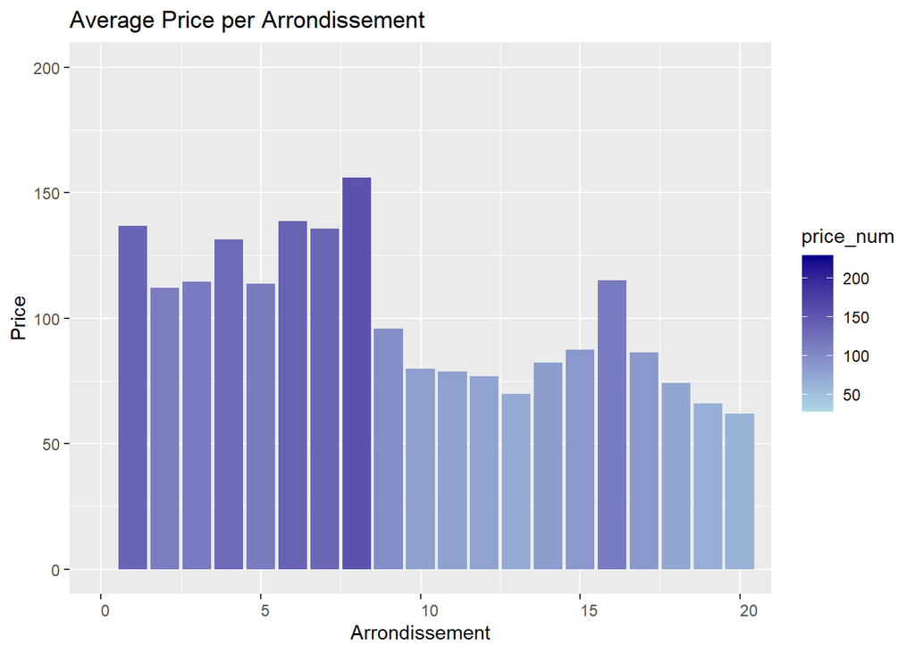

We can also plot the price using a barplot, arranging the bars in decreasing order of price. In this case there are also arrondissements higher than the 20th, however these are probably outliers or wrong data hence shouldn’t be trustworthy.

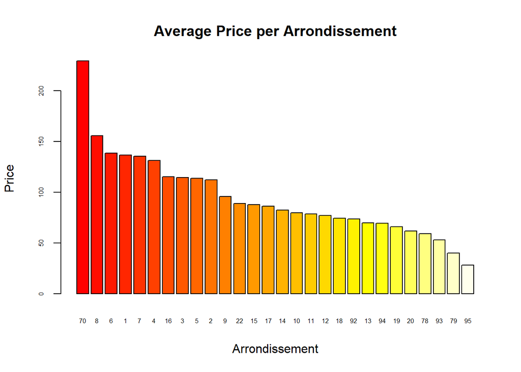

Another interesting visualization related to the location is the plot of the map of Paris with the most relevant monuments. On the Paris map we can overlap the position of the accommodations using their coordinates. From the output we can see that the two are not overlapping perfectly (the black area that represents Paris should be transposed a little bit to the left), still it is possible to see that there are many accommodations outside the centre of Paris, in Boulogne Billancourt. Another interesting thing to notice is that the river Seine is easily recognizable, and the same for the biggest parks of the city. This is because inside the parks and in the river there cannot be accomodations.

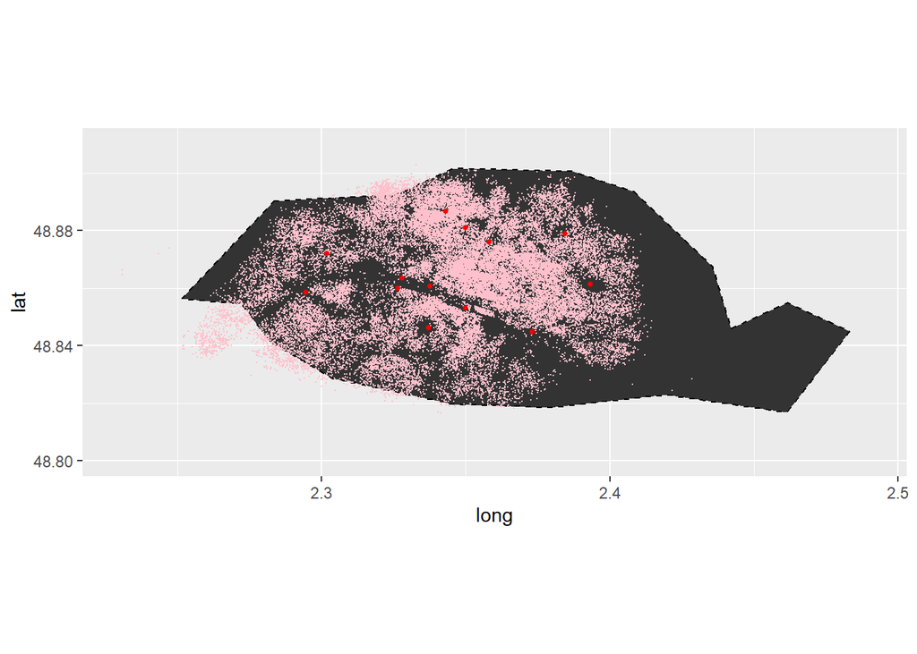

Moreover using the leaflet() function we can show the metropolitan map of Paris to easily identify the biggest gardens of the city as well as the principal neighborhoods. Then we can overlap the accommodations to this map and see that they cover almost the entire available surface of Paris. Zooming in we can see the exact position of the accommodations and which are the monuments and parks in the nearbies.

[interactive chart not shown]

### Analyzing AirbnbR

AirbnbR dataframe has 663599 observations with 2 columns: listing_id and date. These two columns represent the accommodation and the date of the booking of the accommodation. Hence, in this dataset it is normal to have duplicated IDs, but there shouldn’t be duplicated rows since an accommodation can’t be booked twice the same day. There are no missing values in AirbnbR, but there are 3069 duplicates that must be dropped. The datatype of the two columns are integer (for the ID) and character (for the date). In order to analyze the temporal structure of the data, “date” column must be converted into a date format.

```
## Dimension of AirbnbR: 663599 2
```

```
## Column names of AirbnbR: listing_id date
```

```
## Missingness in AirbnbR: 0
```

```
## Starting duplicated values in AirbnbR: 3069
```

```
## Ending duplicated values in AirbnbR: 0
```

```
## Datatype of columns of AirbnbR:
##
```

```
## $listing_id
## [1] "integer"
##
## $date
## [1] "character"
```

- Time related data

With the as.Date function we can convert date column into a date format. Then we can check whether the transformation caused any missing values. Now that we have a date format we can extract year and month to create the month_year column. This column is useful because reduces the number of different values in the column.

```
## Datatype of Date: Date
```

```
## Number of missing values due to change of datatype: 0
```

The first recorded date for the accommodation booking is May 2009 and latest is July 2016. An important thing to notice is that the number of observations increases as the date gets more recent, this could be due to the fact that as time went by many more hosts joined Airbnb with their accommodation. And at the same time tourists and other visitors started to choose an Airbnb’s accommodation instead of a regular hotel. To have a more clear view we can transform the frequency table into a dataframe and arrange it in decreasing order of frequency in order to see which are the month-year with more listings bookings.

```
## Number of listings for each date:
```

```
##
## May 2009 Jun 2009 Jul 2009 Aug 2009 Sep 2009 Oct 2009 Nov 2009 Dec 2009
##        1        5        4        4        7        3        6        9
## Jan 2010 Feb 2010 Mar 2010 Apr 2010 May 2010 Jun 2010 Jul 2010 Aug 2010
##       15       11       22       39       69       63       85       84
## Sep 2010 Oct 2010 Nov 2010 Dec 2010 Jan 2011 Feb 2011 Mar 2011 Apr 2011
##      151      165      105       92      142      104      181      241
## May 2011 Jun 2011 Jul 2011 Aug 2011 Sep 2011 Oct 2011 Nov 2011 Dec 2011
##      315      463      475      395      622      678      556      461
## Jan 2012 Feb 2012 Mar 2012 Apr 2012 May 2012 Jun 2012 Jul 2012 Aug 2012
##      633      412      720     1060     1267     1563     1753     1420
## Sep 2012 Oct 2012 Nov 2012 Dec 2012 Jan 2013 Feb 2013 Mar 2013 Apr 2013
##     2138     2334     1704     1533     2034     1550     2446     3382
## May 2013 Jun 2013 Jul 2013 Aug 2013 Sep 2013 Oct 2013 Nov 2013 Dec 2013
##     4057     4869     4871     3540     5684     5711     4354     4453
## Jan 2014 Feb 2014 Mar 2014 Apr 2014 May 2014 Jun 2014 Jul 2014 Aug 2014
##     5154     3895     5881     8278     9138    11427    11281    10226
## Sep 2014 Oct 2014 Nov 2014 Dec 2014 Jan 2015 Feb 2015 Mar 2015 Apr 2015
##    14405    15858    11595    11650    12960     9688    13796    19450
## May 2015 Jun 2015 Jul 2015 Aug 2015 Sep 2015 Oct 2015 Nov 2015 Dec 2015
##    24127    28853    28907    24260    32272    34370    22960    23201
## Jan 2016 Feb 2016 Mar 2016 Apr 2016 May 2016 Jun 2016 Jul 2016
##    24270    21428    28011    31982    42182    48636     1328
```

```
## Month-year of booking ordered according to number of listings:
```

```
##        Var1  Freq
## 1  Jun 2016 48636
## 2  May 2016 42182
## 3  Oct 2015 34370
## 4  Sep 2015 32272
## 5  Apr 2016 31982
## 6  Jul 2015 28907
## 7  Jun 2015 28853
## 8  Mar 2016 28011
## 9  Jan 2016 24270
## 10 Aug 2015 24260
## 11 May 2015 24127
## 12 Dec 2015 23201
## 13 Nov 2015 22960
## 14 Feb 2016 21428
```

[output cut: 73 more lines]

The airbnb’s listings can also be visualised using the ggplot() function to see the temporal pattern linked to the listings. Indeed, the highest values are in the more recent dates and it is possible to see an increasing pattern with an exponential shape as time goes by.

```
## `geom_line()`: Each group consists of only one observation.
## ℹ Do you need to adjust the group aesthetic?
```

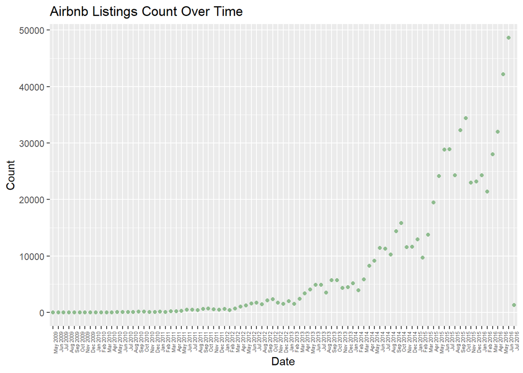

Another way to visualize how the observations are distributed according to the year is a stacked bar. Each rectangle represent a different year and each one is colored in a different way to easily recognize them. The higher the rectangle, the higher number of observations for that year. The years 2009 and 2010 are just very thin lines since they have just a few observation, while the highest rectangle is year 2015. This is because 2016 was observed until July, i.e., almost just half of the year was recorded. This would probably mean that 2016 would be the year with the highest number of listings since 5 months of 2016 were not considered.

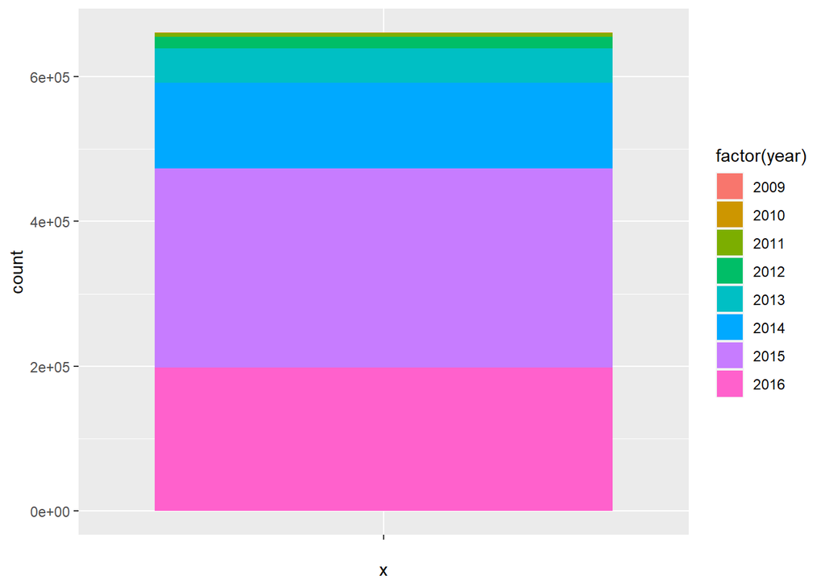

#### Merging AirbnbR and AirbnbL

Merging the dataframes can be useful to combine the information from both datasets based on the common “listing_id” column. By merging the dataframes, there will be a single dataframe “AirbnbMerge” that includes both the listing information from AirbnbL and the corresponding dates from AirbnbR. This provides a more comprehensive dataset that could allow more analysis or modelling.

```
## The dimension of the merged dataframe is:  657968 103
```

```
## Columns of the merged dataframe is:
##
##   id listing_url scrape_id last_scraped name summary space description experiences_offered neighborhood_overview notes transit access interaction house_rules thumbnail_url medium_url picture_url xl_picture_url host_id host_url host_name host_since host_location host_about host_response_time host_…
```

Lastly we should whether the merging created some missing data. In this case there is no missingness and the merged dataset is cleaned and complete.

```
## Number of missing values in the merged dataframe:  0
```